```python
# DSCI 511: Data Acquisition and Pre-Processing <br> Term Project Phase 2: The Project Implementation
```

# Tool for Analysis of Stock Market Assets.

## Copyright (c)

Permission is hereby granted, free of charge, to any person obtaining a copy of this software and associated documentation files (the "Software"), to deal in the Software without restriction, including without limitation the rights to use, copy, modify, merge, publish, distribute, sublicense, and/or sell copies of the Software, and to permit persons to whom the Software is furnished to do so, subject to the following conditions:

The above copyright notice and this permission notice shall be included in all copies or substantial portions of the Software.

THE SOFTWARE IS PROVIDED "AS IS", WITHOUT WARRANTY OF ANY KIND, EXPRESS OR IMPLIED, INCLUDING BUT NOT LIMITED TO THE WARRANTIES OF MERCHANTABILITY, FITNESS FOR A PARTICULAR PURPOSE AND NONINFRINGEMENT. IN NO EVENT SHALL THE AUTHORS OR COPYRIGHT HOLDERS BE LIABLE FOR ANY CLAIM, DAMAGES OR OTHER LIABILITY, WHETHER IN AN ACTION OF CONTRACT, TORT OR OTHERWISE, ARISING FROM, OUT OF OR IN CONNECTION WITH THE SOFTWARE OR THE USE OR OTHER DEALINGS IN THE SOFTWARE.

The implementation of this software requires users to create an account with the developers of the Plygon.IO API.

PLEASE READ THE TERMS OF SERVICE BELOW CAREFULLY BEFORE ACCESSING OR USING THE POLYGON.IO API USED IN THIS SOFTWARE. WHETHER YOU ARE A VISITOR OR A SUBSCRIBER, THE WEBSITE TERMS OF SERVICE APPLY TO YOUR USE OF OUR WEBSITE POLYGON.IO AND ALL WEBPAGES LOCATED WITHIN POLYGON.IO. THE INDIVIDUAL TERMS OF SERVICE, IN ADDITION TO THE WEBSITE TERMS OF SERVICE, APPLY TO YOUR PERSONAL, NON-COMMERCIAL USE OF ANY SERVICE LABELED FOR "INDIVIDUAL USE". THE COMMERCIAL USE TERMS OF SERVICE, IN ADDITION TO THE WEBSITE TERMS OF SERVICE, APPLY TO YOUR INDIVIDUAL OR COMMERCIAL USE OF ANY SERVICE LABELED FOR "COMMERCIAL USE". IF YOU HAVE ANY QUESTIONS, PLEASE CONTACT POLYGON VIA EMAIL AT SUPPORT@POLYGON.IO.

**Abstract**: The data analysts have collected US Stock Market data for the 2022-08-29 to 2023-08-29 period for five different stock assets across the Technology Sector.

**Aim**: To analyze the raw data collected by the Polygon.io stock API, clean the data, i.e., checking for any missing values, converting data formats, selecting variables, etc., and to build data visualizations graphs for monitoring stock trends and behaviors.

**Variable Descriptions (variable name, datatype):**

1. ticker, string: The exchange symbol that this item is traded under.
2. adjusted, boolean: Whether or not this response was adjusted for splits.
3. queryCount, integer: The number of aggregates (minute or day) used to generate the response.
4. request_id, string: A request id assigned by the server.
5. resultsCount, integer: The total number of results for this request.
6. status, string: The status of this request's response.
7. results, dict array (up to 10 elements):
   1. c, real number: The close price for the symbol in the given time period.
   2. h, real number: The highest price for the symbol in the given time period.
   3. l, real number: The lowest price for the symbol in the given time period.
   4. n, integer: The number of transactions in the aggregate window.
   5. o, real number: The open price for the symbol in the given time period.
   6. otc, boolean: Whether or not this aggregate is for an OTC ticker. This field will be left off if false.
   7. t, integer: The Unix Msec timestamp for the start of the aggregate window.
   8. v, real number: The trading volume of the symbol in the given time period.
   9. vw, real number: The volume weighted average price.
   10. next_url, string: If present, this value can be used to fetch the next page of data.
8. BackTest Output, object
   1. Start: is the specific date set for starting a stock's backtests.
   2. End: is the specific date set for ending a stock's backtests.
   3. Duration: total number of days a trader holds a stock.
   4. Exposure Time [%]: the percentage of days that money is invested in the stock market.
   5. Equity Final [$]:  the amount of money in a trader's account after all trades have been closed.
   6. Equity Peak [$]:  the largest amount of money in a trader's account when trading orders are active.
   7. Return [%]: is the total percentage profit or loss of a strategy over a specific period of time.
   8. Buy & Hold Return [%]: is the percentage return achieved when a trader holds a stock for the duration of a test period.
   9. Return (Ann.) [%]: "annualized return" metric used to measure the average percentage rate of return on a stock over a year, taking into account compounding.
   10. Volatility (Ann.) [%]: "annualized volatility" is a metric used in to measure the risk of a strategy by calculating the standard deviation of its daily returns over a year.
   11. Sharpe Ratio: a risk-adjusted trading performance measure.
   12. Sortino Ratio: a risk-adjustment metric used to determine the additional return for each unit of downside risk.
   13. Calmar Ratio: a metric used to evaluate a stock fund's performance compared to its risk.
   14. Max. Drawdown [%]: a statistic used to measure the maximum of all the drawdown values after each closed trade. It indicates the maximum loss suffered by the strategy at any point during the backtest.
   15. Avg. Drawdown [%]: a statistic used to measure the average of all the drawdown values after each closed trade. It indicates the average loss suffered by the strategy during the backtest.
   16. Max. Drawdown Duration: the largest duration of drawdown periods.
   17. Avg. Drawdown Duration: the average duration of drawdown periods.
   18. Win Rate [%]: performance metric of the success rate of a trader's strategy [(winning trades/total no. of trades) x 100].
   19. Best Trade [%]: trade with the maximum day return value [(maximum day returns/total trades returns) * 100]
   20. Worst Trade [%]: trade with the minimum day return value [(minimum day returns/total trades returns) * 100]
   21. Avg. Trade [%]: the average amount of money gained or lost per trade.
   22. Max. Trade Duration: longest timeframe in days used to start the backtesting of a trading strategy.
   23. Avg. Trade Duration: average timeframe in days used to start the backtesting of a trading strategy.
   24. Profit Factor: metric used to evaluate the profitability of trading strategies by backtesting them against historical data.
   25. Expectancy [%]: metric used to measure the performance of trading strategies by estimating how much money a trader can expect to make or lose per trade on average.
   26. SQN: System Quality Number (SQN) score describes the daily % change for input over a 100-day period.
   27. _strategy: internal parameter in backtesting.py used to set performance indicator applied in the buy/sell strategy.
   28. _equity_curve: internal parameter in backtesting.py.
   29. _trades: internal parameter in backtesting.py.

# In this notebook, we analyze stock market data collected via the Polygon.IO API.

## Flow:

1. Data Downloading
2. Reading & Understanding Data Types
3. Data Preprocessing (Variable Selection)
4. Data Exploration
   1. Exploring Historical Stock Trends (--using interactive candlestick charts--)
   2. Exploring Stock Buy/Sell Strategies (--by analysis of EMS, SMA and RSI Indicators, and corresponding interactive charts--)
5. Interpretation of Stock Trends and Strategy Analyzes
6. Learnings & Conclusion
7. References

### The following the project aim we'll works towards finding answers for the following questions:

1. What are the query parameters, rate limits and response object of the API?
2. What are the relevant query parameters and why are they important?
3. What are the relevant variables in the dataset and why are they important?
4. What are some of the best indicators to use for understanding the target variable?
5. What does the dataset look like in terms of its size, structure, and content?
6. Is the dataset complete, or are there any missing values that need to be imputed?
7. How useful or interpretable is the data?

The Five Stock Market Assets Under Consideration in this Project are:

1. APPLE INC **(AAPL)**,
2. TESLA INC **(TSLA)**,
3. META PLATFORMS INC **(META)**,
4. ALPHABET INC CLASS C **(GOOG)**,
5. AMAZON.COM INC **(AMZN)**

**NOTE: Please refer to the "requirements.txt" file for information about the required packages to run this Python Project**

```python
#imports for data collection via PolygonAPI
from polygon import rest
from typing import cast
from urllib3 import HTTPResponse
import config #where an individual user's API_Key should be stored

#imports for data processing and visualization
import json
import pandas as pd
from dash import Dash, html, dcc
from dash.dependencies import Input, Output
import matplotlib
matplotlib.use('Agg')
from plotly import graph_objects as go
```

# 1. Data Downloading

```python
client = rest.RESTClient(config.API_KEY)

aggs = cast(
    HTTPResponse,
    client.get_aggs(
        'AAPL',
        1,
        'day',
        '2022-08-29',
        '2023-08-29',
        adjusted=True,
        raw=True,
        limit=5000
    )
)

poly_data = json.loads(aggs.data)
df = pd.DataFrame(poly_data)
```

# 2. Data Reading & Understanding

## Reading data

```python
with pd.option_context('display.max_rows', 10, 'display.max_columns', None,'display.max_colwidth', None):
    display(df)
```

|  | ticker | queryCount | resultsCount | adjusted | results | status | request_id | count |
| --- | --- | --- | --- | --- | --- | --- | --- | --- |
| 0 | AAPL | 252 | 252 | True | {'v': 73313953.0, 'vw': 161.5291, 'o': 161.145, 'c': 161.38, 'h': 162.9, 'l': 159.82, 't': 1661745600000, 'n': 640593} | OK | de635bdf0891a137c94a53ca2035cd9d | 252 |
| 1 | AAPL | 252 | 252 | True | {'v': 77906197.0, 'vw': 159.2926, 'o': 162.13, 'c': 158.91, 'h': 162.56, 'l': 157.72, 't': 1661832000000, 'n': 644671} | OK | de635bdf0891a137c94a53ca2035cd9d | 252 |
| 2 | AAPL | 252 | 252 | True | {'v': 87991091.0, 'vw': 158.3972, 'o': 160.305, 'c': 157.22, 'h': 160.58, 'l': 157.14, 't': 1661918400000, 'n': 606827} | OK | de635bdf0891a137c94a53ca2035cd9d | 252 |
| 3 | AAPL | 252 | 252 | True | {'v': 74229896.0, 'vw': 156.5232, 'o': 156.64, 'c': 157.96, 'h': 158.42, 'l': 154.67, 't': 1662004800000, 'n': 654667} | OK | de635bdf0891a137c94a53ca2035cd9d | 252 |
| 4 | AAPL | 252 | 252 | True | {'v': 76807768.0, 'vw': 157.6597, 'o': 159.75, 'c': 155.81, 'h': 160.362, 'l': 154.965, 't': 1662091200000, 'n': 646414} | OK | de635bdf0891a137c94a53ca2035cd9d | 252 |
| ... | ... | ... | ... | ... | ... | ... | ... | ... |
| 247 | AAPL | 252 | 252 | True | {'v': 52722752.0, 'vw': 180.6482, 'o': 178.52, 'c': 181.12, 'h': 181.55, 'l': 178.325, 't': 1692763200000, 'n': 587165} | OK | de635bdf0891a137c94a53ca2035cd9d | 252 |
| 248 | AAPL | 252 | 252 | True | {'v': 54912798.0, 'vw': 177.7035, 'o': 180.674, 'c': 176.38, 'h': 181.104, 'l': 176.01, 't': 1692849600000, 'n': 610377} | OK | de635bdf0891a137c94a53ca2035cd9d | 252 |
| 249 | AAPL | 252 | 252 | True | {'v': 51439994.0, 'vw': 177.9075, 'o': 177.38, 'c': 178.61, 'h': 179.15, 'l': 175.82, 't': 1692936000000, 'n': 554789} | OK | de635bdf0891a137c94a53ca2035cd9d | 252 |
| 250 | AAPL | 252 | 252 | True | {'v': 43803238.0, 'vw': 179.6595, 'o': 180.09, 'c': 180.19, 'h': 180.59, 'l': 178.545, 't': 1693195200000, 'n': 532485} | OK | de635bdf0891a137c94a53ca2035cd9d | 252 |
| 251 | AAPL | 252 | 252 | True | {'v': 52953948.0, 'vw': 183.28, 'o': 179.695, 'c': 184.12, 'h': 184.9, 'l': 179.5, 't': 1693281600000, 'n': 576465} | OK | de635bdf0891a137c94a53ca2035cd9d | 252 |

252 rows × 8 columns

## Understanding data

```python
df.info()
```

```
<class 'pandas.core.frame.DataFrame'>
RangeIndex: 252 entries, 0 to 251
Data columns (total 8 columns):
 #   Column        Non-Null Count  Dtype
---  ------        --------------  -----
 0   ticker        252 non-null    object
 1   queryCount    252 non-null    int64
 2   resultsCount  252 non-null    int64
 3   adjusted      252 non-null    bool
 4   results       252 non-null    object
 5   status        252 non-null    object
 6   request_id    252 non-null    object
 7   count         252 non-null    int64
dtypes: bool(1), int64(3), object(4)
memory usage: 14.2+ KB
```

# 3. Data Preprocessing (Variable Selection)

## Downloading & reading selected data

```python
poly_data = json.loads(aggs.data)
df = pd.DataFrame(poly_data['results'])

with pd.option_context('display.max_rows', 10, 'display.max_columns', None,'display.max_colwidth', None):
    display(df)
```

|  | v | vw | o | c | h | l | t | n |
| --- | --- | --- | --- | --- | --- | --- | --- | --- |
| 0 | 73313953.0 | 161.5291 | 161.145 | 161.38 | 162.900 | 159.820 | 1661745600000 | 640593 |
| 1 | 77906197.0 | 159.2926 | 162.130 | 158.91 | 162.560 | 157.720 | 1661832000000 | 644671 |
| 2 | 87991091.0 | 158.3972 | 160.305 | 157.22 | 160.580 | 157.140 | 1661918400000 | 606827 |
| 3 | 74229896.0 | 156.5232 | 156.640 | 157.96 | 158.420 | 154.670 | 1662004800000 | 654667 |
| 4 | 76807768.0 | 157.6597 | 159.750 | 155.81 | 160.362 | 154.965 | 1662091200000 | 646414 |
| ... | ... | ... | ... | ... | ... | ... | ... | ... |
| 247 | 52722752.0 | 180.6482 | 178.520 | 181.12 | 181.550 | 178.325 | 1692763200000 | 587165 |
| 248 | 54912798.0 | 177.7035 | 180.674 | 176.38 | 181.104 | 176.010 | 1692849600000 | 610377 |
| 249 | 51439994.0 | 177.9075 | 177.380 | 178.61 | 179.150 | 175.820 | 1692936000000 | 554789 |
| 250 | 43803238.0 | 179.6595 | 180.090 | 180.19 | 180.590 | 178.545 | 1693195200000 | 532485 |
| 251 | 52953948.0 | 183.2800 | 179.695 | 184.12 | 184.900 | 179.500 | 1693281600000 | 576465 |

252 rows × 8 columns

## Understanding selected data

```python
df.info()
```

```
<class 'pandas.core.frame.DataFrame'>
RangeIndex: 252 entries, 0 to 251
Data columns (total 8 columns):
 #   Column  Non-Null Count  Dtype
---  ------  --------------  -----
 0   v       252 non-null    float64
 1   vw      252 non-null    float64
 2   o       252 non-null    float64
 3   c       252 non-null    float64
 4   h       252 non-null    float64
 5   l       252 non-null    float64
 6   t       252 non-null    int64
 7   n       252 non-null    int64
dtypes: float64(6), int64(2)
memory usage: 15.9 KB
```

# 4. Data Exploration

## Retrieving selected stock data from AAPLE, Tesla, Meta, Google and Amazon.com

```python
client = rest.RESTClient(config.API_KEY)

#setup dash
app = Dash(__name__)

app.layout = html.Div([
    html.H1('Stock Graphs  --select a stock asset from dropdown menu--'),
    dcc.Dropdown(id='stock-list',
    options = [
        {'label': 'Apple', 'value':'AAPL'},
        {'label': 'Tesla', 'value':'TSLA'},
        {'label': 'Meta', 'value':'META'},
        {'label': 'Google', 'value':'GOOG'},
        {'label': 'Amazon', 'value':'AMZN'}
    ],
    value = 'AAPL' # Apple as default value in dropdown menu
    ),
    dcc.Graph(id='Stock-graph'),
    ],
    style={'width':'500'}
    )
```

## A. Historical stock trends using interactive candlestick charts

```python
#Callback decorator
@app.callback(Output('Stock-graph', 'figure'), [Input('stock-list', 'value')])

def graph(selected_dropdown_value):

    aggs = cast(
        HTTPResponse,
        client.get_aggs(
            selected_dropdown_value,
            1,
            'day',
            '2022-08-29',
            '2023-08-29',
            adjusted=True,
            raw=True,
            limit=5000

        ),

    )
    data = json.loads(aggs.data)

    for item in data:
        if item == 'results':
            rawData = data[item]

    closelist = []
    openlist = []
    highlist = []
    lowlist = []
    #volumelist = []#too much data for candlestick
    timelist = []

    for bar in rawData:
        for category in bar:
            if category == 'c':
                closelist.append(bar[category])
            elif category == 'o':
                openlist.append(bar[category])
            elif category == 'h':
                highlist.append(bar[category])
            elif category == 'l':
                lowlist.append(bar[category])
            elif category == 't':
                timelist.append(pd.Timestamp(bar[category], tz='GMT', unit='ms'))#to change GMT and milisecond formats

    fig = go.Figure()
    fig.add_trace(go.Candlestick(x=timelist, close=closelist, open=openlist, high=highlist, low=lowlist, name='Stock Data'))
    fig.update_layout(xaxis_rangeslider_visible=False, template='plotly_dark') #to eliminate slider plotly outputs by default and use dark mode
    return fig

if __name__ == '__main__':
    app.run_server(debug=True, port=8050)

#Alternative access to charts by pasting this link, http://127.0.0.1:8050/ , on web browser
```

[interactive chart not shown]

# B. Strategies for buying and selling stocks

### Select a stock asset for the calculations -- enter stock ticker at prompt, and then press the "enter" key on keyboard

```python
varname = input().upper()
varname
```

```
'AAPL'
```

## Calculating the Exponential Moving Average (EMA) indicator

```python
import talib
import numpy as np
import datetime as dt
```

```python
def getData():
     client = rest.RESTClient(config.API_KEY)
     closelist = []
     timelist = []
     #endDate = dt.datetime.today().date()#can be used for dynamic time/date updating (from 2022-08-23 onwards)

     aggs = cast(
        HTTPResponse,
        client.get_aggs(
        varname,
        1,
        'day',
        '2022-08-29',
        '2023-08-29',
        adjusted=True,
        raw=True,
        limit=5000
            ),
    )
     data = json.loads(aggs.data)
     bars = data['results']

     for bar in bars:
         for value in bar:
             if value == 'c':
                 closelist.append(bar[value])
             elif value == 't':
                 timelist.append(pd.Timestamp(bar[value], tz='GMT', unit='ms'))

     #convert closelist into a numpy array for data processing using talib
     closelist = np.array(closelist)
     #get talib EMAs
     ema_eight = talib.EMA(closelist, 8)
     ema_thirteen = talib.EMA(closelist, 13)
     ema_twentyone = talib.EMA(closelist, 21)
     ema_fiftyfive = talib.EMA(closelist, 55)

     print(f'\n\033[1mEMA_50 calculations for {varname} stocks:\n\033[0m')

     # checking for date when EMA_55 crosses above or under the other EMAs,
     # which marks the entry/buy and the exit/sell points, respectively.
     for i in range(len(ema_fiftyfive)):
         if (ema_fiftyfive[i] > ema_eight[i]) and (ema_fiftyfive[i] > ema_thirteen[i]) and (ema_fiftyfive[i] > ema_twentyone[i]):
             print("EMA_50 has crossed ABOVE ALL other EMAs on: " + str(timelist[i]) )
         elif(ema_fiftyfive[i] < ema_eight[i]) and (ema_fiftyfive[i] < ema_thirteen[i]) and (ema_fiftyfive[i] < ema_twentyone[i]):
             print("EMA_50 has crossed UNDER ALL other EMAs on: " + str(timelist[i]) )
getData()
```

```
EMA_50 calculations for AAPL stocks:

EMA_50 has crossed ABOVE ALL other EMAs on: 2022-11-14 05:00:00+00:00
EMA_50 has crossed ABOVE ALL other EMAs on: 2022-11-15 05:00:00+00:00
EMA_50 has crossed ABOVE ALL other EMAs on: 2022-11-16 05:00:00+00:00
EMA_50 has crossed ABOVE ALL other EMAs on: 2022-11-17 05:00:00+00:00
EMA_50 has crossed ABOVE ALL other EMAs on: 2022-11-18 05:00:00+00:00
EMA_50 has crossed ABOVE ALL other EMAs on: 2022-11-21 05:00:00+00:00
EMA_50 has crossed ABOVE ALL other EMAs on: 2022-11-22 05:00:00+00:00
EMA_50 has crossed ABOVE ALL other EMAs on: 2022-11-28 05:00:00+00:00
EMA_50 has crossed ABOVE ALL other EMAs on: 2022-11-29 05:00:00+00:00
EMA_50 has crossed ABOVE ALL other EMAs on: 2022-11-30 05:00:00+00:00
EMA_50 has crossed ABOVE ALL other EMAs on: 2022-12-01 05:00:00+00:00
EMA_50 has crossed ABOVE ALL other EMAs on: 2022-12-02 05:00:00+00:00
EMA_50 has crossed ABOVE ALL other EMAs on: 2022-12-05 05:00:00+00:00
EMA_50 has crossed ABOVE ALL other EMAs on: 2022-12-06 05:00:00+00:00
EMA_50 has crossed ABOVE ALL other EMAs on: 2022-12-07 05:00:00+00:00
EMA_50 has crossed ABOVE ALL other EMAs on: 2022-12-08 05:00:00+00:00
EMA_50 has crossed ABOVE ALL other EMAs on: 2022-12-09 05:00:00+00:00
EMA_50 has crossed ABOVE ALL other EMAs on: 2022-12-12 05:00:00+00:00
EMA_50 has crossed ABOVE ALL other EMAs on: 2022-12-13 05:00:00+00:00
EMA_50 has crossed ABOVE ALL other EMAs on: 2022-12-14 05:00:00+00:00
EMA_50 has crossed ABOVE ALL other EMAs on: 2022-12-15 05:00:00+00:00
EMA_50 has crossed ABOVE ALL other EMAs on: 2022-12-16 05:00:00+00:00
EMA_50 has crossed ABOVE ALL other EMAs on: 2022-12-19 05:00:00+00:00
EMA_50 has crossed ABOVE ALL other EMAs on: 2022-12-20 05:00:00+00:00
EMA_50 has crossed ABOVE ALL other EMAs on: 2022-12-21 05:00:00+00:00
EMA_50 has crossed ABOVE ALL other EMAs on: 2022-12-22 05:00:00+00:00
EMA_50 has crossed ABOVE ALL other EMAs on: 2022-12-23 05:00:00+00:00
EMA_50 has crossed ABOVE ALL other EMAs on: 2022-12-27 05:00:00+00:00
EMA_50 has crossed ABOVE ALL other EMAs on: 2022-12-28 05:00:00+00:00
EMA_50 has crossed ABOVE ALL other EMAs on: 2022-12-29 05:00:00+00:00
EMA_50 has crossed ABOVE ALL other EMAs on: 2022-12-30 05:00:00+00:00
EMA_50 has crossed ABOVE ALL other EMAs on: 2023-01-03 05:00:00+00:00
EMA_50 has crossed ABOVE ALL other EMAs on: 2023-01-04 05:00:00+00:00
EMA_50 has crossed ABOVE ALL other EMAs on: 2023-01-05 05:00:00+00:00
EMA_50 has crossed ABOVE ALL other EMAs on: 2023-01-06 05:00:00+00:00
EMA_50 has crossed ABOVE ALL other EMAs on: 2023-01-09 05:00:00+00:00
EMA_50 has crossed ABOVE ALL other EMAs on: 2023-01-10 05:00:00+00:00
EMA_50 has crossed ABOVE ALL other EMAs on: 2023-01-11 05:00:00+00:00
```

[output cut: 132 more lines]

```
EMA_50 has crossed UNDER ALL other EMAs on: 2023-08-01 04:00:00+00:00
EMA_50 has crossed UNDER ALL other EMAs on: 2023-08-02 04:00:00+00:00
EMA_50 has crossed UNDER ALL other EMAs on: 2023-08-03 04:00:00+00:00
EMA_50 has crossed UNDER ALL other EMAs on: 2023-08-04 04:00:00+00:00
EMA_50 has crossed UNDER ALL other EMAs on: 2023-08-07 04:00:00+00:00
EMA_50 has crossed UNDER ALL other EMAs on: 2023-08-08 04:00:00+00:00
EMA_50 has crossed ABOVE ALL other EMAs on: 2023-08-17 04:00:00+00:00
EMA_50 has crossed ABOVE ALL other EMAs on: 2023-08-18 04:00:00+00:00
EMA_50 has crossed ABOVE ALL other EMAs on: 2023-08-21 04:00:00+00:00
EMA_50 has crossed ABOVE ALL other EMAs on: 2023-08-22 04:00:00+00:00
EMA_50 has crossed ABOVE ALL other EMAs on: 2023-08-23 04:00:00+00:00
EMA_50 has crossed ABOVE ALL other EMAs on: 2023-08-24 04:00:00+00:00
EMA_50 has crossed ABOVE ALL other EMAs on: 2023-08-25 04:00:00+00:00
EMA_50 has crossed ABOVE ALL other EMAs on: 2023-08-28 04:00:00+00:00
EMA_50 has crossed ABOVE ALL other EMAs on: 2023-08-29 04:00:00+00:00
```

## Calculating the Simple Moving Average (SMA) and the Relative Strength Index (RSI) indicators

```python
from backtesting import Backtest, Strategy
from backtesting.lib import crossover
from backtesting.test import SMA
import warnings
warnings.filterwarnings('ignore')
```

Loading BokehJS ...

### Select moving averages for SMA calculations -- enter day-period at prompt, and then press the "enter" key on keyboard

```python
n1 = int(input())
n2 = int(input())
print (f'Entered moving averages are: the {n1}-day and {n2}-day periods. -- value=10 and value=20, are the typically used values, respectively')
```

```
Entered moving averages are: the 10-day and 20-day periods. -- value=10 and value=20, are the typically used values, respectively
```

### Select upper, lower & RSI window values for RSI calculations -- enter values at prompt, and then press the "enter" key on keyboard

```python
upper_bound = int(input())
lower_bound = int(input())
rsi_window = int(input())
print(f'Entered values: upper boundary is {upper_bound}, lower boundary is {lower_bound} and rsi moving window is {rsi_window}')
print('-- value=70, value=30, and value=14, are the typically used values, respectively')
```

```
Entered values: upper boundary is 70, lower boundary is 30 and rsi moving window is 14
-- value=70, value=30, and value=14, are the typically used values, respectively
```

```python
client = rest.RESTClient(config.API_KEY)

aggs = cast(
    HTTPResponse,
    client.get_aggs(
        varname,
        1,
        'day',
        '2022-08-29',
        '2023-08-29',
        adjusted=True,
        raw=True,
        limit=5000
    )
)

poly_data = json.loads(aggs.data)
poly_data = poly_data['results'] #to get the bars data only (e.g., o, h, l, etc.)

dates = []
for bar in poly_data:
    for item in bar:
        if item == 't':
            dates.append(pd.Timestamp(bar[item], tz='GMT', unit='ms').date())

df = pd.DataFrame(poly_data)

d = {'Open' : df['o'], 'High' : df['h'], 'Low' : df['l'], 'Close': df['c'], 'Volume': df['v']} #get only bars needed for backtesting

dataFrame = pd.DataFrame(d)
pd.DateTimeIndex = dates #displays graph but no dates
#dataFrame.index = dates #first codeline tried but not working


#uncomment lines below to pirnt and compare df's
# print(df)
# print(dataFrame)

#Backtesting analysis SMA and RSI

class smacross(Strategy):
    def init(self):
        #n1 = 10
        #n2 = 20
        price = self.data.Close
        self.sma1 = self.I(SMA, price, n1)
        self.sma2 = self.I(SMA, price, n2)

    def next(self):
        if crossover(self.sma1, self.sma2):
            self.buy()
        elif crossover(self.sma2, self.sma1):
            self.sell()
bt = Backtest(dataFrame, smacross, commission =0.002, exclusive_orders=True) #exclusive_orders is an optional arg

print(f'\n\033[1mSMA Backtest Output on {varname} Stocks (Stats & Interactive Charts):\n\033[0m.')
print(bt.run())
print()
stats = bt.run()
bt.plot()



class rsioscillator(Strategy): #using typical values as described in talib and backtesting github page
    upper_bound = upper_bound
    lower_bound = lower_bound
    rsi_window = rsi_window

    def init(self):
        self.rsi = self.I(talib.RSI, self.data.Close, self.rsi_window)

    def next(self):
        if crossover(self.rsi, self.upper_bound):
            self.position.close()
        elif crossover(self.lower_bound, self.rsi):
            self.buy()
bt = Backtest(dataFrame, rsioscillator, cash=10000, commission=.002)

print(f'\n\033[1mRSI Backtest Output on {varname} Stocks (Stats & Interactive Charts):\n\033[0m.')
print(bt.run())
print()
stats = bt.run()
bt.plot()
```

```
SMA Backtest Output on AAPL Stocks (Stats & Interactive Charts):
.
Start                                     0.0
End                                     251.0
Duration                                251.0
Exposure Time [%]                   83.730159
Equity Final [$]                  11070.16096
Equity Peak [$]                   12114.74814
Return [%]                           10.70161
Buy & Hold Return [%]               14.090965
Return (Ann.) [%]                         0.0
Volatility (Ann.) [%]                     NaN
Sharpe Ratio                              NaN
Sortino Ratio                             NaN
Calmar Ratio                              0.0
Max. Drawdown [%]                  -19.314955
Avg. Drawdown [%]                   -3.454427
Max. Drawdown Duration                   66.0
Avg. Drawdown Duration              11.166667
# Trades                                  8.0
Win Rate [%]                             37.5
Best Trade [%]                      17.857083
Worst Trade [%]                     -6.625541
Avg. Trade [%]                       1.311261
Max. Trade Duration                      99.0
Avg. Trade Duration                     26.25
Profit Factor                         1.65182
Expectancy [%]                       1.616668
SQN                                  0.474854
_strategy                            smacross
_equity_curve                       Equity...
_trades                      Size  EntryBa...
dtype: object
```

```
RSI Backtest Output on AAPL Stocks (Stats & Interactive Charts):
.
Start                                     0.0
End                                     251.0
Duration                                251.0
Exposure Time [%]                    40.47619
Equity Final [$]                  10666.22934
Equity Peak [$]                   11242.25776
Return [%]                           6.662293
Buy & Hold Return [%]               14.090965
Return (Ann.) [%]                         0.0
Volatility (Ann.) [%]                     NaN
Sharpe Ratio                              NaN
Sortino Ratio                             NaN
Calmar Ratio                              0.0
Max. Drawdown [%]                   -19.67434
Avg. Drawdown [%]                  -10.033708
Max. Drawdown Duration                  208.0
Avg. Drawdown Duration              74.333333
# Trades                                  2.0
Win Rate [%]                             50.0
Best Trade [%]                       6.891347
Worst Trade [%]                     -0.196824
Avg. Trade [%]                       3.286475
Max. Trade Duration                      85.0
Avg. Trade Duration                      50.0
Profit Factor                       35.012777
Expectancy [%]                       3.347262
SQN                                  0.940941
_strategy                       rsioscillator
_equity_curve                       Equity...
_trades                      Size  EntryBa...
dtype: object
```

**GridPlot**(

id = 'p1614', …)

# 5. Interpretation of Stock Trends and Strategy Results

## Understanding and Interpreting Candlestick Charts:

In order to create a candlestick chart, a dataset must contain open, high, low and close (OHLC) values for each time period you want to display. Values for volume may also be added to the dataset. Here, we wrote code and used the Dash|Plotly library to generate interactive candlestick charts for the targeted US stocks (Figure 1). One can note in Fig. 1, that for the 1-year period 2022-08-29 to 2023-08-29, META's chart is comprised of candlesticks with bodies that are more compacted (shorter), while candlesticks in Amazon's trend show longer body. Generally speaking, the longer the body of the candlestrick is, the more intense the buying or selling pressure is. Conversely, short candlesticks indicate little price movement and represent consolidation.

**FIGURE 1**

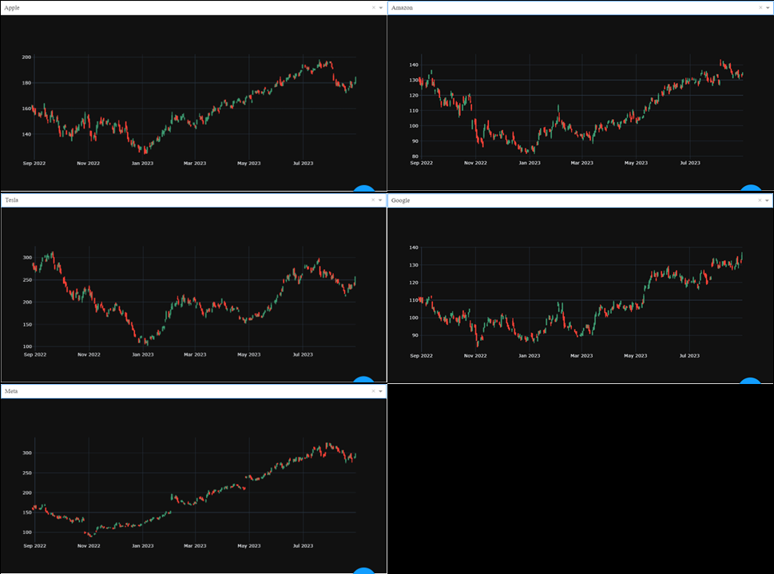

**FIGURE 2**

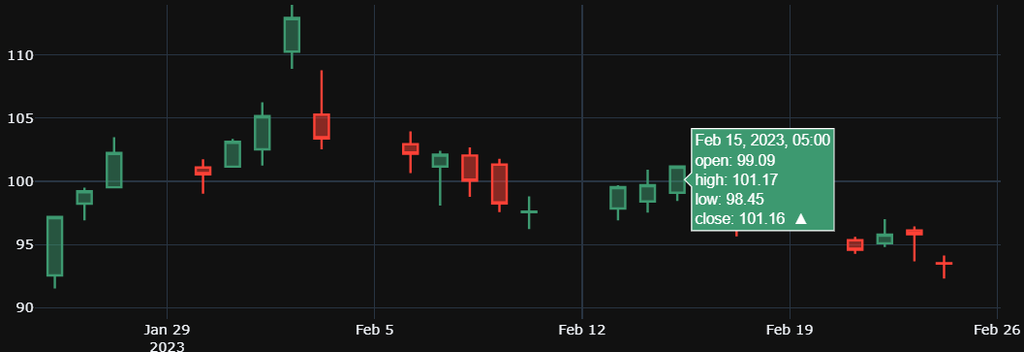

**FIGURE 3**

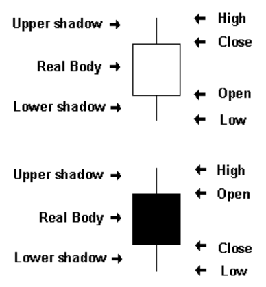

## Understanding and Interpreting Backtesting Strategy Results:

In our Python tool, we compute the EMS, SMA and RSI indicators for implemeting a backtesting strategy. Like in the case of candlestick charts, a dataset must contain OHLC values for each time period considered when computating these three indicators. Values for volume may also be added to the dataset, which are then included in the candlesticks charts returned in the respective backtesting results.

Backtesting is the general method for seeing how well a strategy or a predictive model would have done after the fact **[3]**. In other words, backtesting is method that helps traders and investors simulate their trading strategies on past (historical) data to gauge their effectiveness and potential profitability before using them in real-time trading. When traders are backtesting a day trading strategy (15-minute timeframe or lower), it is usually enough to go back two to three months and start the backtest there. When traders are backtesting a strategy on a higher timeframe, they will have to go back 6 to 12 months **[4]**.

In backtesting, the EMA gives more weight to the most recent prices, thereby aligning the average closer to current prices. In general, short-term traders typically rely on the 12- or 26-day EMA, while the ever-popular 50-day and 200-day EMA is used by long-term investors **[5]**. Like all moving averages, this technical indicator is used to produce buy and sell signals based on crossovers and divergences from the historical average **[3]**. Figure 4, show the output (results) provided in our tool for APPLE stocks (trading period 2022-08-29 to 2023-08-29). Such data, can help traders/investors track and indentify EMA crossovers.

**FIGURE 4**

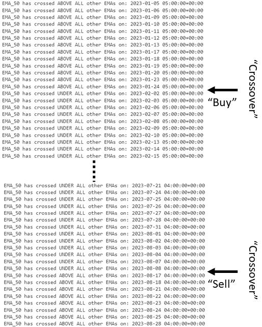

For backtesting with SMA and RSI indicators, we incorporated user-defined input variables that allow the trader to "tweak" our system. We also added statistical and interactive functionalities to allow traders to experience more insights.

In backtesting, the SMA helps traders identify the direction of a market trend by averaging the closing prices of a stock over a specified period. This strategy is commonly employed to smooth out price data by creating a constantly updated average price, which can assist traders in making decisions about whether to buy or sell a financial instrument. The length of the SMA can vary depending on the trader’s time horizon and goals; shorter moving averages are typically used for short-term trading, while longer averages are favored for longer-term investment decisions. On the other hand, in backtesting, the RSI help traders validate trading strategies based on the indicator. The RSI is a technical indicator that measures the momentum and strength of price movements. The RSI oscillates between zero and 100, and is traditionally considered overbought when above 70 and oversold when below 30. Traders can use these levels as potential sell and buy signals, respectively.

**FIGURE 5**

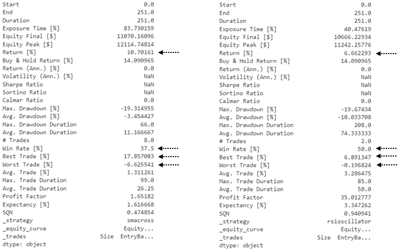

In addition to statiscal performance measurments, our system provides interactive charts for the visualization of SMA and RSI crossovers. These charts are composed of four to five graph subsets. Three that track Equity, Profit / Losses, and Volume, and, in the case of the RSI backtesting strategy, a fourth to track RSI crossovers. Results also include corresponding candlestick charts. Users can access relevant information (over 7 attributes) by hovering the cursor over any of our graph subsets (Fig. 6).The points where SMA1 cross over SMA2, would signal traders to buy stock. Conversely, points where SMA2 corss over SMA1 would signal traders to sell.

**FIGURE 6**

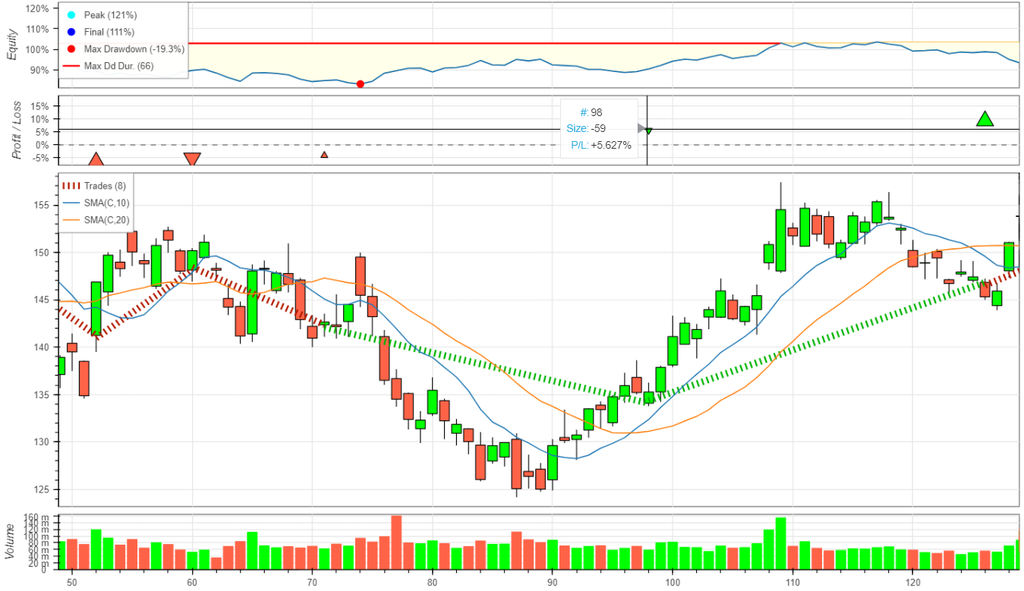

# 6. Learnings & Conclusions

The Polygon.io Stock Options API provides REST endpoints that let users query the latest market data from all US options exchanges. Users can find data on active and historical data. The free tier subscription of the API limits API requests to 5 API requests per minute, limits access to historical data (<1.5 years), and limits the number of base aggregates queried to create the aggregate results (Max = 50000). As shown in the "Variable Description" at the top of this notebook, data requests are set through several parameter options. One can get aggregate bars for an option contract over a given date range in custom time window sizes. For example, if timespan = ‘minute’ and multiplier = ‘5’ then 5-minute bars will be returned. Parameter options to sort results by timestamp are also available. For instance, the asc option will return results in ascending order (oldest at the top), and desc will return results in descending order (newest at the top). Other extended query parameters are also available (see References Section below for links to full list of query parameter options offered by the API). By default, the API returns all endpoints as a JSON response, which can be modified to a CSV response if so desired.

The most relevant query parameters are the stocksTicker, which specify a case-sensitive stock symbol (e.g., 'AAPL' for Apple Inc); the multiplier, which specify the size of the timespan multiplier; the timespan, which specify the size of the time window (e.g., by day, by week, etc., by second, by hour, etc.); and the start date and end date parameters, which specify the returned results lower and upper date ranges, respectively. In regards to the timestamps, the response returns data in UNIX timestamps (i.e., UTC/GMT time), and in miliseconds, we needed to write code lines to parse such data into a local timezone and YYYY-MM-DD format.

The JSON response returns valid data for the Stock Market trading periods, i.e., no endpoints with timespans outside the Open and Close periods are returned. Additionally, only endpoints with timespans during a stock's trading period (if not traded daily) are returned. These two features of the API response prevented the need of having to impute a variable's value for the analyses conducted herein.

The most relevant variables returned in the JSON response are found in the 'results', which are shown and described in the Variable Description at the top of this notebook. The variables contained in the 'results' provide the necessary information for traders and investors to understand the status of their stocks assets and the equity they hold. These variables are critical in many types of analysis directed at maximizing profits and minimalizing losses, for example, analyses for building stock portfolios, for devising a stock buying/selling strategy, etc. Herein, such variables were used for the computation of performance metrics and "indicators" relevant to a trader's buy or sell decision.

There are several indicators that can be used by investors or traders to make financially smart buy or sell decisions **[1]**. Some indicators are more specialized for particular types of investments (e.g., options or Cryptocurrency) **[2]** **[3]**, and some are completely spurious in nature **[4]** **[5]**. They all have pros and cons, therefore, investors and traders typically use and compare two or more indicators for making holding or exiting decisions. There are also different approaches for using or testing a stock's performance with such indicators. For example, backtesting allows users to test their investment ideas or trading systems against historical data to evaluate their performance under various market conditions, while Forward testing, also known as paper trading, provides traders a mechanism for the simulation of actual trading and involves following the system's logic in a live market. It is also called paper trading since all trades are executed on paper only; that is, trade entries and exits are documented along with any profit or loss for the system, but no real trades are executed **[6]** In this notebook we use backtesting for three commonly employed trading indicators, namely, EMA, SMA, and RSI.

In conclusion, we learned the challenges involved in building a complex computational framework for the development of a backtesting software. For instance, we foresee the need for containerization. The sheer number of dependencies among software and library packages employed in our software tool (e.g. dash, bokeh, etc.) makes our computational framework prone to breakages associated with version changes in the Python ecosystem. We also conclude, that in order to turn our tool into an application comparable to the more reliable, useful and practical trading software in the market, we will need to upgrade our Polygon API service free subscription to a paid subscription. This will allow us to gain access to the historical data and a much larger sized dataset. Such changes would also allow us to explore the development and inclusion of statistical and machine-learning techniques for the prediction of future stock performance based on a stock's past performance. Finally, we recognize the need for incorporating domain expertise into our team to further develop our system.

# 7. References

**A. URL's with documentation of sortwares and libraries used for this project (url's last tested on 06/06/2024):**

1. Stock Market API (version 1.2.0): https://polygon.io/
2. Stocks API Documentation: https://polygon.io/docs/stocks/getting-started
3. Polygon.IO API and Webpage Terms of Service: https://polygon.io/terms
4. Backtesting.py (version 0.3.3): https://kernc.github.io/backtesting.py/doc/backtesting/#gsc.tab=0
5. Technical Analysis Library (Ta-Lib, version 0.4.29): https://hexdocs.pm/talib/api-reference.html
6. Dash (version 2.17.0): https://dash.plotly.com/
7. Bokeh (version 3.2.1): https://docs.bokeh.org/en/latest/
8. matplotlib (version 3.8.4): https://matplotlib.org/stable/users/index.html
9. numpy (version 1.26.4): https://numpy.org/doc/
10. plotly (version 5.22.0): https://plotly.github.io/plotly.py-docs/generated/plotly

**B. URL's with tutorials relevant to the topics treated in this project (url's last tested on 06/06/2024):**

1. EMA Strategy as way to Know When to Buy or Sell Stocks: [https://www.youtube.com/watch?v=kGZh6X8HBw8\n](https://www.youtube.com/watch?v=kGZh6X8HBw8%5Cn)
2. How to Use the Relative Strength Index (RSI): https://www.youtube.com/watch?v=hbcCykbX14U
3. EMA vs SMA - How to find the perfect Moving Average as a trader: https://www.youtube.com/watch?v=Z_gVO1FcXhs
4. How To Use 20 SMA (Simple Moving Average): https://www.youtube.com/watch?v=WYiTLT9kwCQ

**C. References cited in "Interpretation of Stock Trends and Strategy Results" (Section 5) in this notebook (url's last tested on 06/06/2024):**

1. Alan Northcott (2009). "The Complete Guide to Using Candlestick Charting: How to Earn High Rates of Return - Safely," Pages 15–17. Atlantic Publishing Group.
2. Cory Mitchell (2024). Understanding Basic Candlestick Charts. Investopedia, February 28, 2024. Url: https://www.investopedia.com/trading/candlestick-charting-what-is-it/
3. James Chen (2024). Backtesting: Definition, How It Works, and Downsides. Investopedia, April 11, 2024. Url: https://www.investopedia.com/terms/b/backtesting.asp
4. Tradeciety Group (2023). THE ULTIMATE GUIDE TO BACKTESTING. Tradeciety, December 5, 2023. Url: https://tradeciety.com/the-ultimate-guide-to-backtesting
5. J.B. Maverick (2024). How Is the Exponential Moving Average (EMA) Formula Calculated?, Investopedia, April 30, 2024. Url: https://www.investopedia.com/ask/answers/122314/what-exponential-moving-average-ema-formula-and-how-ema-calculated.asp#:~:text=The%20exponential%20moving%20average%20(EMA)%20is%20a%20technical%20chart%20indicator,importance%20to%20recent%20price%20data.
6. Niclas Hummel (2023). System Quality Number (SQN). Medium Blog, October 28, 2023. Url: https://medium.com/@niclas_hummel/system-quality-number-sqn-cb04cf7e9ecd#:~:text=The%20System%20Quality%20Number,indicates%20its%20stability%20or%20consistency.

**D. References cited in "Learning & Conclusions" (Section 6) in this notebook (url's last tested on 06/06/2024):**

1. Saxo Group, Saxo Bank A/S. A guide to the 10 most popular trading indicators. Url: https://www.home.saxo/learn/guides/trading-strategies/a-guide-to-the-10-most-popular-trading-indicators
2. CoinDCX (2023). Top 10 Technical Indicators for Crypto Trading & Analysis. In CoinDCX Blog, November 9, 2023. Url: https://coindcx.com/blog/cryptocurrency/10-best-indicators-for-crypto-trading
3. Shobhit Seth (2024). The Top Technical Indicators for Options Trading. Investopedia, May 17, 2024. Url: https://www.investopedia.com/articles/active-trading/101314/top-technical-indicators-options-trading.asp
4. Robert Farrington (2023). 6 Weird But Successful Indicators For Stocks. The College Investor,June 19, 2023. Url: https://thecollegeinvestor.com/1666/weird-stock-market-indicators/
5. Rob Wile (2012). 15 Of The Most Spurious Correlations In The Stock Market. BusinessInsider Newsletter, April 19, 2012. Url: https://www.businessinsider.com/15-spurious-stock-correlations-2012-4
6. Jean Folger (2022). Backtesting and Forward Testing: The Importance of Correlation. Investopedia.com, July 12, 2022. Url: https://www.investopedia.com/articles/trading/10/backtesting-walkforward-important-correlation.asp